# Vignette illustrating the use of sparse SMOFA on simulated data with a temporal covariate

Britta Velten

17 February 2020

#### Package

SMOFA 0.99.0

# Contents

```r
devtools::load_all(".")
library(tidyverse)
library(pheatmap)
```

# 1 Data: Simulate an example data set

```r
set.seed(2020)

# number of views and samples
M <- 4
N <- 400

# generate example data
dd <- make_example_data(n_samples = N, n_features = 500,
                        n_views = M, lscales = c(100, 30, 0,0))

# mask some samples in some views
mask <- sample(1:N, N*0.1*M, replace = TRUE)
# mask <- split(mask, 1:M)
# dd$data <- lapply(1:M, function(m) {
#   mdd <- dd$data[[m]]
#   mdd[, mask[[m]]] <- NA
#   mdd
#   })
```

# 2 SMOFA

## 2.1 Create a SMOFA object

To create a SMOFA objevt we need to specify the training data and (optionally) the covariates for pattern detection and inerence of smooth factors. Here, `sample_cov` is a matrix with samples in columns and covariates in rows. The sample order must match the order in data columns. Alternatively, a data frame can be provided containung one `sample` columns with samples names matching the sample names in the data.

```r
sm <- create_smofa(data = dd$data, sample_cov = dd$sample_cov)
sm
```

```
## Untrained SMOFA model with the following characteristics:
##  Number of views: 4
##  Views names: view_1 view_2 view_3 view_4
##  Number of features (per view): 500 500 500 500
##  Number of covariates: 1
##  Number of samples: 400
```

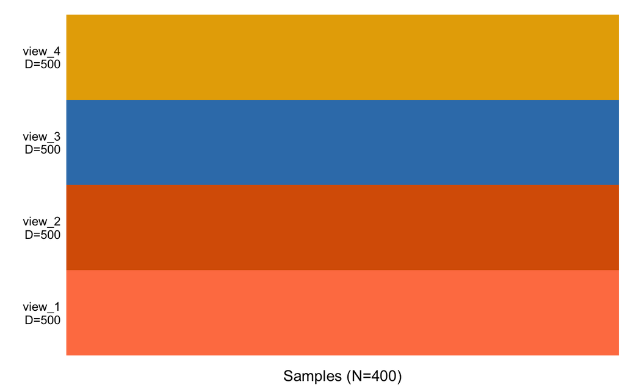

```r
plot_data_overview(sm)
```

## 2.2 Prepare a SMOFA object

Before training, we can specify various options for the model, the training and the data preprocessing. If no options are specified, the model will use the default options. See also `get_default_data_options`, `get_default_model_options` and `get_default_training_options` to have a look at the defaults and change them where required. Here, we drop factors that explain less than 1% of variance in the data starting from 10 factors. We use a grid of 50 points to optimise the lengthscale of each factor and make use of sparse Gaussian process inference by setting `sparseGP` to TRUE. This results in a faster inference compared to modelling the full covariance matrix.

```r
train_opt <- get_default_training_options(sm)
train_opt$drop_factor_threshold <- 0.01
train_opt$seed <- 1234567
train_opt$maxiter <- 300
model_opts <- get_default_model_options(sm)
model_opts$num_factors <- 10
model_opts$mv_Znode <- TRUE
model_opts$sparseGP <- TRUE
model_opts$n_inducing <- 0.5*N
model_opts$n_grid <- 50
model_opts$seed_inducing <- 1234567
sm <- prepare_smofa(sm, training_options = train_opt, model_options = model_opts)
```

## 2.3 Run SMOFA

Now, the SMOFA object is ready for training. Using `run_smofa` we can fit the model, which is saves in the file specified as `outfile`. If none is specified the output is only saved in a temporary location.

```r
sm <- run_smofa(sm)
```

[output not shown]

## 2.4 Down-stream analysis

### 2.4.1 Variance explained per factor

Using `plot_variance_explained` we can explore which factor is active in which view. `plot_factor_cor` shows us whether the factors are correlated.

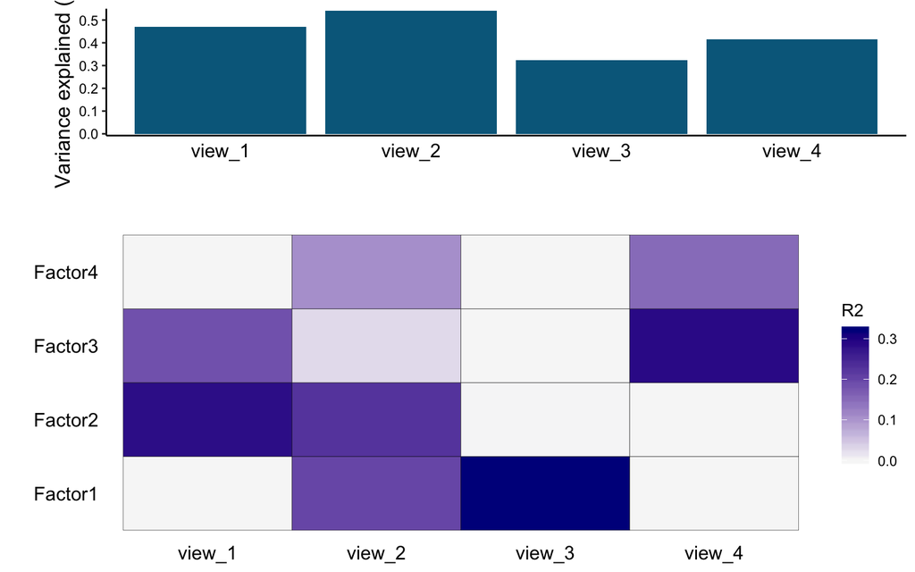

```r
plot_variance_explained(sm,plot_total = T)
```

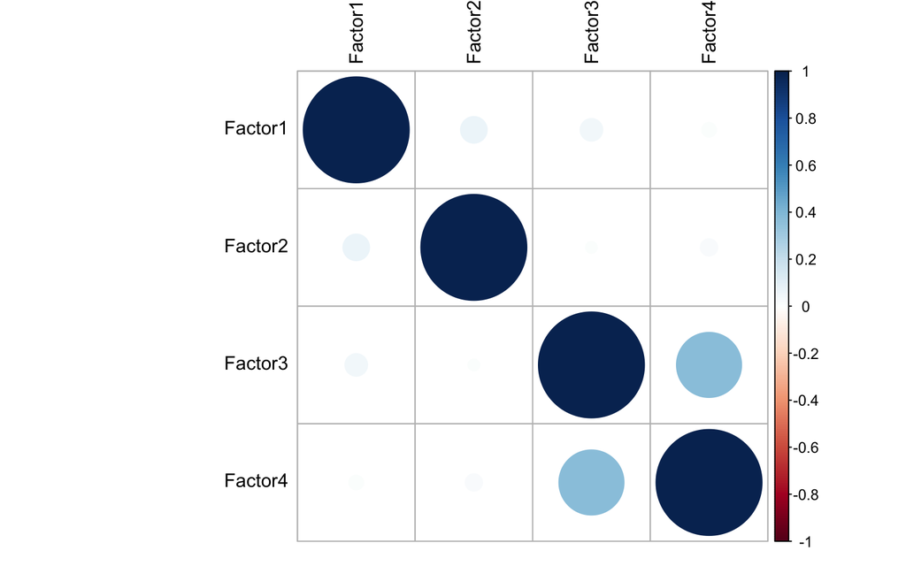

```r
r <- plot_factor_cor(sm)
```

```r
get_lengthscales(sm)
```

```
##   Factor1   Factor2   Factor3   Factor4
##  0.000000  0.000000 25.034474  2.618293
```

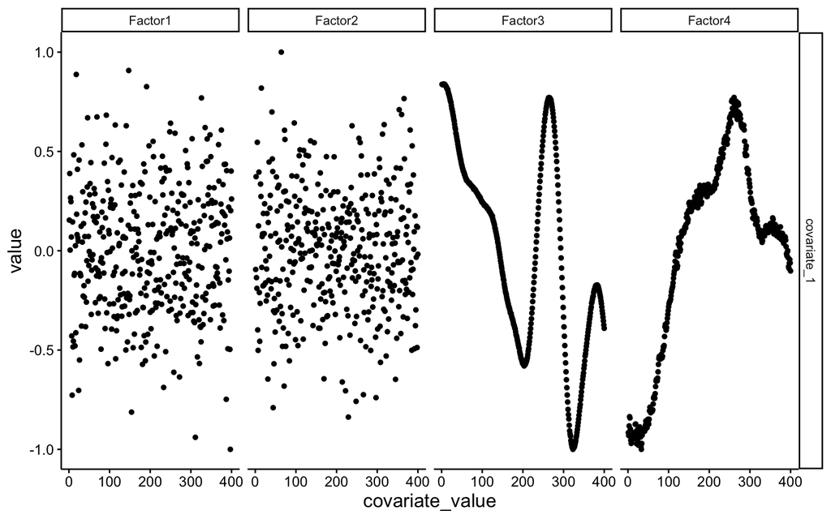

```r
plot_factors_vs_cov(sm, scale = TRUE)
```

We can compare this to the factors that were simulated:

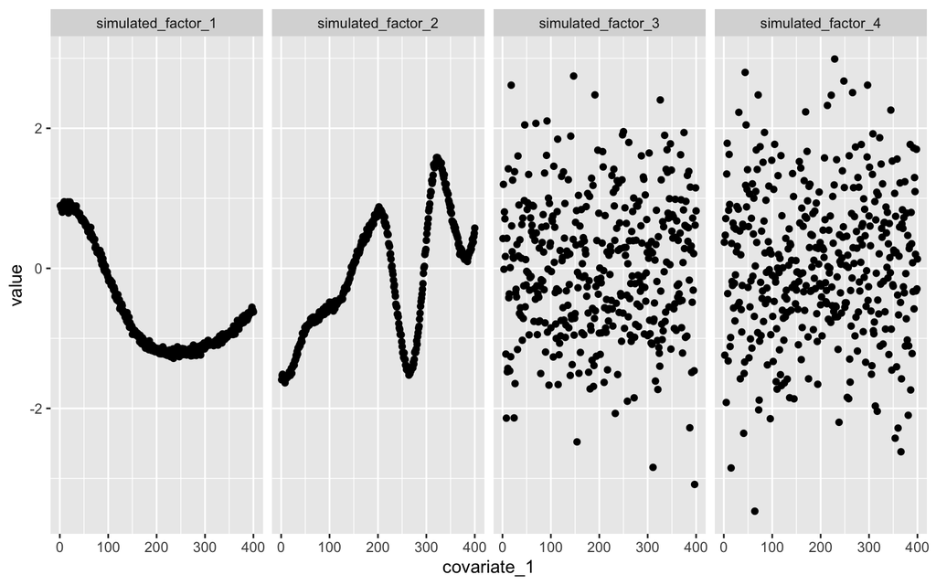

```r
df <- data.frame(dd$Z, get_covariates(sm, as.data.frame = T))
df <- gather(df, key = "factor", value = "value", starts_with("simulated_factor"))
ggplot(df, aes(x =covariate_1, y = value)) + geom_point() + facet_grid(~factor)
```

### 2.4.2 Exploration of weights

As with MOFA(+) we can now look deeper into the meaning of these factors by exploring the weigths or performing feature set enrichment analysis.

```r
# plot_weights(sm, factors = 4, view = 1)
# plot_top_weights(sm, factors = 3, view = 2)
```

# 3 Alternative options and comparisons

## 3.1 Standard MOFA(+) (without covariates)

When we do not specify any sample covariates or set `GP_factors` to `FALSE`, the model falls back to the standard MOFA model. We train this here as a comparison.

```r
# create new SMOFA object (note we could also set sample_cov to NULL)
sm_nocov <- create_smofa(data = dd$data, sample_cov = dd$sample_cov)
```

```
## Creating SMOFA object from a list of matrices (features as rows, sample as columns)...
```

```
## No sample names in covariates - using the sample names provided in data for covariates.
```

```r
# set options
train_opt <- get_default_training_options(sm_nocov)
train_opt$drop_factor_threshold <- 0.01
train_opt$seed <- 1234567
model_opts <- get_default_model_options(sm_nocov)
model_opts$num_factors <- 10
model_opts$GP_factors <- FALSE

# Prepare and train the SMOFA object
sm_nocov <- prepare_smofa(sm_nocov, training_options = train_opt, model_options = model_opts)
```

```
## Checking data options...
```

```
## No data options specified, using default...
```

```
## Checking training options...
```

```
## Checking model options...
```

```r
sm_nocov <- run_smofa(sm_nocov)
```

[output not shown]

```
## No covariate names provided, using generic names: covariate_1,....covariate_C
```

[output not shown]

### 3.1.1 Variance explained per factor

As above, we use `plot_variance_explained` to explore which factor is active in which view. `plot_factor_cor` shows us whether the factors are correlated.

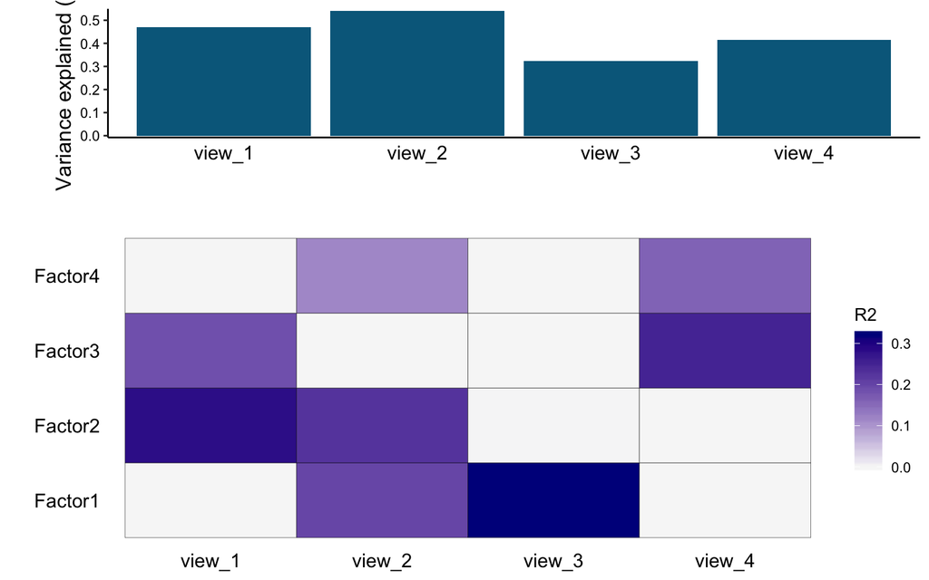

```r
plot_variance_explained(sm_nocov,plot_total = T)
```

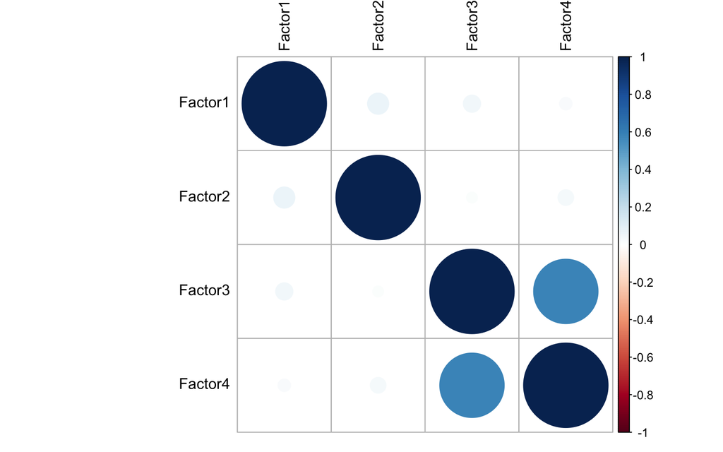

```r
r <- plot_factor_cor(sm_nocov)
```

### 3.1.2 Relate factors to the covariate

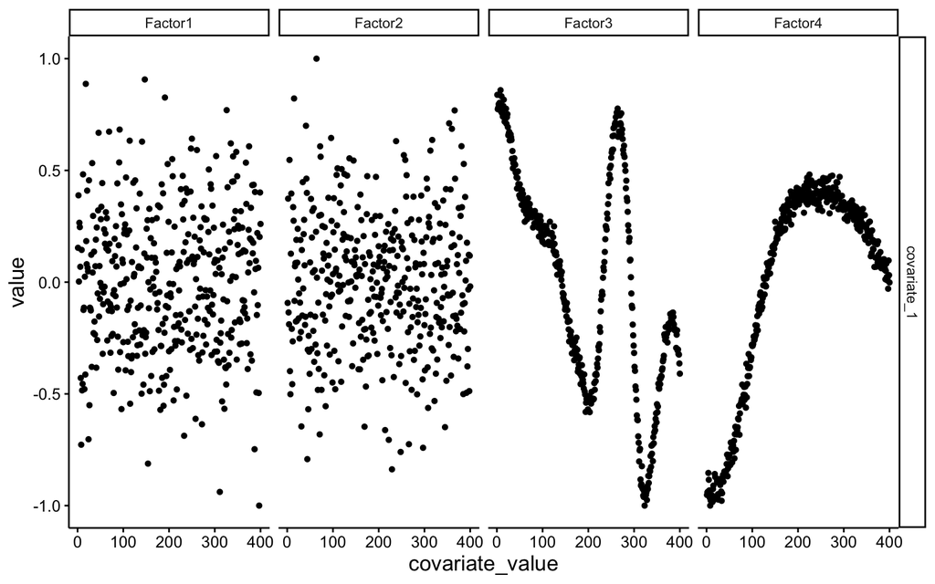

```r
plot_factors_vs_cov(sm_nocov, scale = TRUE)
```

## 3.2 Comparison of factor smoothness between models

Compare simulated and inferred factors including the posterior variance of factor values (illustrating the uncertainty of the factor values). Note that factors can be flipped (mirrored at the x-axis) and in a different order compared to the simulated factors due to the symmetry of the model.

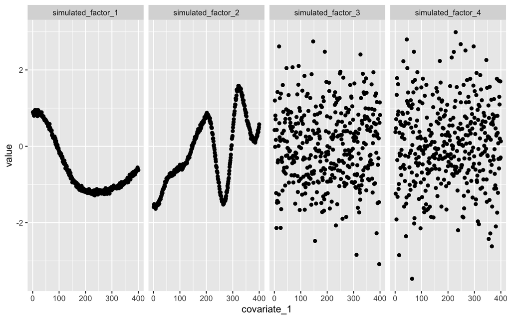

```r
df <- data.frame(dd$Z, get_covariates(sm, as.data.frame = T))
df <- gather(df, key = "factor", value = "value", starts_with("simulated_factor"))
ggplot(df, aes(x =covariate_1, y = value)) + geom_point() + facet_grid(~factor)
```

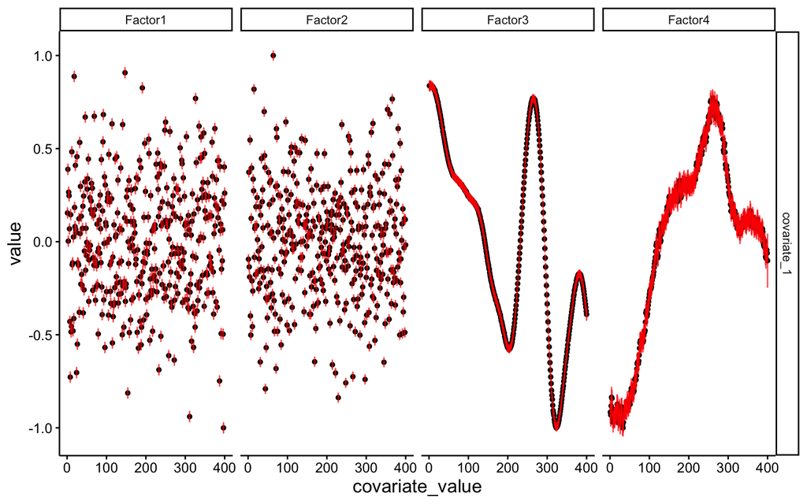

```r
plot_factors_vs_cov(sm, scale = TRUE, show_variance = TRUE)
```

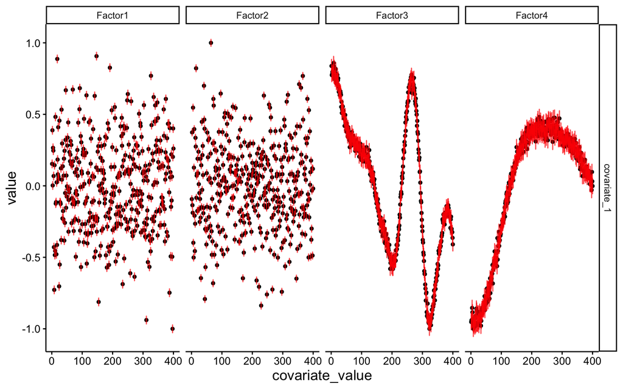

```r
# plot_factors_vs_cov(sm_univ, scale = TRUE, show_variance = TRUE)
plot_factors_vs_cov(sm_nocov, scale = TRUE, show_variance = TRUE)
```